# Blogging about Political Economy and Data Science

Robert Myles McDonnell

2018-03-07

I’ve been thinking about changing the tone and content of this blog for a little while now. I started out writing about IRT models, Bayesian stats and stuff like that, and then I started sharing some R code for various little tasks, along with some tips and tricks, or blogging about some of my R packages. However, the blogosphere is full of great R (or Python etc.) people who share code snippets and tips & tricks ([hrbrmstr](https://rud.is/b/) and [curso-R](http://curso-r.com/blog/) being particularly good ones). I’ll still do that when I find something interesting to share, but I’d like to move more in the direction of my current interests, that marshy ground where politics and economics combine. I’ll call it Political Economy, since that’s what it used to be called before the British economist Alfred Marshall decided we should separate the two and study economics in mathematical detail. Given that I have some R skillz, I’m going to combine it all into a lovely mash. Political Economy and R (maybe some Python, some JavaScript). Great.

So a few provisos before we start: I’m not a ‘trained’ economist, in the sense that I have no formal economics qualifications. I do have a PhD in International Relations (IR), and since I’ve never believed in the artificial separation of politics and economics, I took and interest in International Political Economy since the start of my formal IR studies back in 2009 (and I was informally interested in it earlier). So this blog will be a chance for me to educate myself and to share that process (comments and corrections are of course always welcome). It is inspired somewhat by [Cafe Hayek](http://cafehayek.com/), and by the fact that I noticed that I regularly read things that irritate me. They irritate me because they’re wrong, and they are part of accepted wisdom. Since I do not have either the deep knowledge or the academic pedigree to simply lecture people on the fact that they are wrong (like the estimable Dr. Boudreaux), I will attempt to use my R skills, and my data analysis and data science skills to empirically or statistically highlight my points, where I can. The topics? Stuff that irritates me.

I should be clear too, about where I stand on all these things. Since I read Cafe Hayek, it might be obvious. I share the politics of the left, in the sense that I think we should all work towards eliminating poverty and improving the lives of regular people, and that I think social freedoms are important. I share the politics of the right in the sense that I believe in a free market. The problem with the right and the left is that the right doesn’t actually believe in a free market, they just think they do, while the left is obsessed with implementing policies that clearly don’t work. The fact that they don’t work is so clear that I often wonder if people on the left do actually care about what they say they care about.

So what do I believe in? A free society, with as much liberty as possible. What does this look like? Small government? Yes, because the ‘private sector’, in other words, society, can provide services and goods better and cheaper. And if you think that ‘small government’ is a thing of the right, take a look at the military and security expenditures of any Western country with a conservative government. They don’t believe in small government. A free market? Absolutely, but there are some important points to be made here. Following Marx (and Marshall), people seem to think that the ‘market’ is some abstract thing that exists, independent of us. The market is *us*. A ‘free’ market is impossible in a non-free society. Freedom is what is important – the freedom to worship whatever god you want, dress how you want, marry who you want, engage in whatever sexual behaviour you like, buy and sell whatever you want, read what you want, say what you want, live where you want, work with whatever pleases you – these are the fundamental liberties of society. Are they absolutes? Of course not. There are boundaries and lines that we negoatiate, as a society, but the focus should always be on maximising freedom *between consenting citizens*. So no, you shouldn’t be able to marry a goat, sorry to let you down on that one. And to point out the obvious, your freedom ends at hurting others, you don’t get to do that.

So why blog about this stuff? Like I mentioned, one part of it is to educate myself and to refine my thinking on these matters. I regularly receive emails about R stuff from my other blog posts, so I hope people engage with me on these topics too. I am also no economist – so let’s hope I learn plenty on the way too. Another important point is that I see that most people want the same as I do – fairness, prosperity, liberty, security – but are (in my view) mistaken about how to achieve this. There are many little fallacies all around us, committed on a daily basis, particularly in newspapers, as Don Boudreaux points out day after day. I will attempt to combine Mr. Boudreax’s knowledge of the economy (I don’t have it, I learn from him and others like him, like the wonderful Deirdre McCloskey) with data analysis. Maybe some of these targets won’t even be worth taking on, but I’m tired of reading misguided nonsense in widely-read media outlets (I’m looking at you, *Guardian*). This nonsense is not just an irritation, it is dangerous. Journalists recommending clampdowns on economic freedom don’t seem to realise that this is a clampdown on freedom everywhere. And the clamdowns always come in the form of the government ‘doing something’. I wonder who on the left would accept a government clampdown on art, literature, music and poetry?

You might notice that I mention the left a lot. This is because, like I said, I share more affinity with the left. Apologies, but I have no love for hierarchy and order and conservatism. Right-wing people claim to love free trade and free markets, but then talk about ‘winning’ ‘trade wars’. Junk. And I doubt they welcome creative destruction (i.e. the upending of hierarchy and order), which is a fundamental (perhaps *the* fundamental) aspect of a free market. I doubt it because they are conservatives, and conservatives are not liberals.

Ah, yes, ‘liberals’. That is another point worth noting, because a ‘liberal’, particulary in the United States, means ‘left-wing’. The reality is that left-wing ‘liberals’ are in fact statist Progressives, that is, they want the state to implement policies to move society in the direction they want. They *might* be liberal on social policy, but they are totally anti-liberal on economic policy, and fail to see that the power they transfer to governments in order to regulate trade doesn’t stop at trade. The distaste for commerce and profits is also hypocritical, since the arts are patronised by such filthy lucre (I know, my undergraduate degree is in Fine Art – I wrote and performed pieces of theatre and made installations). So I will use the term ‘liberal’ in its real sense. A liberal is someone who welcomes liberty at all levels – economic, private, social, moral – and sees little justification for government intrusion into our lives. That is not to say there is no role for government. As Professor McCloskey writes, there is space for a ‘motherly libertarianism’, in which the state can do things it may excel at (it excels at very few things), or at least we can implement innovative solutions to state-caused problems. Others, like Murray Rothbard, would no doubt disagree. We’ll see. I’m learning.

I wrote ‘libertarianism’ above. This is also a point worth mentioning. The word ‘libertarian’ conjures notions of right-wing gun nuts (at least it does for us Europeans). It is true that many libertarians would defend gun rights, but this is strongly linked to the freedom of the individual. On point of principle, no government should have the right to stop you buying or selling guns. However, we all see the damage that they can cause. Like I said, this one of those things we negotiate as a society. Anyway, I’ll use the word ‘liberal’, ‘libertarian’ can stay with those who think that statist Progressives can somehow be considered liberal.

### First Up

So where to start? Let’s start with my favourite, the Guardian. The Guardian has excellent sports coverage (I love rugby union), so I regularly read it. But it’s economic coverage (mainly on the opinion pages) is downright dangerous. In fact it’s quite insane. On the same day, you can read a socialist argument for controlling the economy, and criticism of Donald Trump’s anti-trade policies being bad for society. I kid you not, the Guardian wallows in cognitive dissonance. Let’s start with something I read today. The title of the piece when I first read it was something like *‘Get real, Jamie Oliver: middle-class diets need middle-class incomes’*, however, when I went back, it had been changed. The article still seems the same, though. You can read it [here](https://www.theguardian.com/commentisfree/2018/mar/07/jamie-oliver-poor-people-diet-tips-obesity-class).  
Here’s the backgound to this article: Britain, like other rich countries, has an obesity problem. Jamie Oliver (a TV chef and entrepreneur, if you don’t know him) has been for many years campaigning for more awareness of healthy food in Britain, at one point sucessfully implenting healthy school meals in schools in England. Jamie suggested recently that porr people think ‘in a different gear’ when it comes to healthy food, as they are too busy trying to get enough money to buy enough food to feed their families in the first place, and that this leaves them in a difficult position to even start thinking about healthy diets. The columnist in question, Kathleen Kerridge, writes that poor people do indeed know how to cook, that “they are not avoiding broccoli because they’re too stupid to cook it”, and that cost is the defining factor in determing what people eat.  
Leaving aside the common observation that there are McDonalds and KFCs everywhere, which means people like them and are prepared to pay money to eat there (and should be able to spend their money on whatever they like), there are other factors at play that are more interesting. The ‘unseen’, as [Bastiat](http://www.econlib.org/library/Bastiat/basEss1.html) would have put it.

First of all, why can’t people afford fruit and vegetables? While top-quality food and exotic fruits will always be expensive, I can’t think of a reason why fruit and vegetables would be *a priori* expensive in the UK. I mean, ok, the UK imports something like half its food. It’s a small country, and supposedly quite densely populated. So maybe land prices are too high to produce food, and then the UK has to import it? Perhaps, but it’s still no reason for it to be expensive, especially since its EU partner France produces more than enough to feed itself and export to its neighbour. Not to mention the Southern European countries, all food producers and members of the trade bloc.

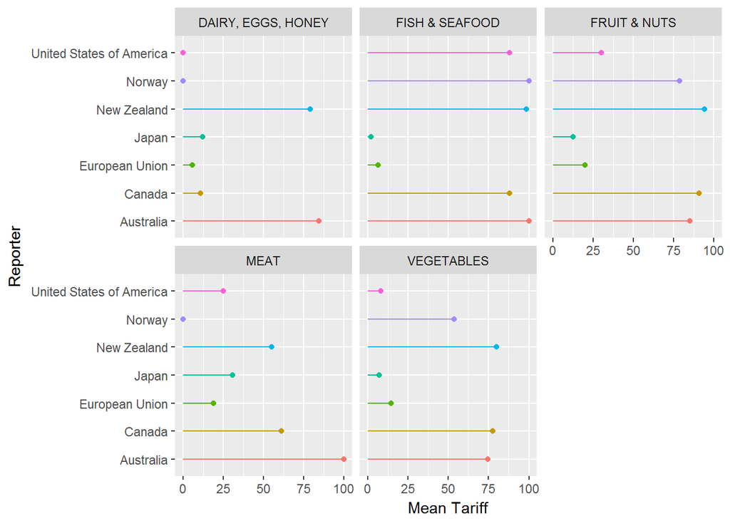

```r
library(tidyverse)

tariffs <- read_tsv("C:/Users/robert.m.mcdonnell/Documents/temp/Applied_MFN_Tariffs.txt")

tariffs %>% filter(Year == 2017) %>%
  select(Reporter, `Percent duty free`, Description, Product) %>%
  filter(Product %in% c("02", "03", "04", "07", "08")) %>%
  mutate(Description = case_when(Product == "02" ~ "MEAT",
                                 Product == "03" ~ "FISH & SEAFOOD",
                                 Product == "04" ~ "DAIRY, EGGS, HONEY",
                                 Product == "07" ~ "VEGETABLES",
                                 TRUE ~ "FRUIT & NUTS")) %>%
  group_by(Description, Reporter) %>%
  summarise(`Mean Tariff` = mean(`Percent duty free`)) %>%
  ggplot(aes(x = `Mean Tariff`, y = Reporter, colour = Reporter)) +
  geom_point() + facet_wrap(~ Description) +
  geom_segment(aes(x = 0, xend = `Mean Tariff`, yend = Reporter)) +
  theme(legend.position = "none")
```